# Fall 2020 - Math 421 - Midterm

## II. Data Visualization

Continue with the data from part I.

1. Provides at least 10 meaningful plots. Comments on the plots. All plots should have title, caption, appropriate labels on x and y-axis

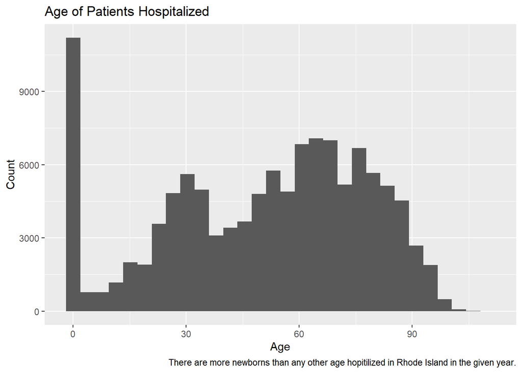

```r
library(tidyverse)
df1 %>% ggplot()+
  geom_histogram(mapping = aes(x = age))+
  labs(x='Age',
       y = 'Count',
       title = 'Age of Patients Hospitalized',
       caption = 'There are more newborns than any other age hopitilized in Rhode Island in the given year.')
```

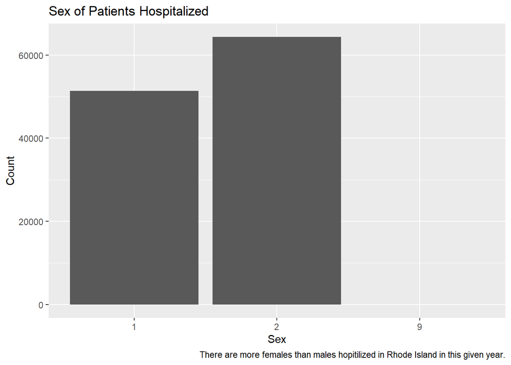

```r
df1$sex <- as.character(df1$sex)
df1 %>% ggplot()+
  geom_bar(mapping = aes(x = sex))+
  labs(x='Sex',
       y = 'Count',
       title = 'Sex of Patients Hospitalized',
       caption = 'There are more females than males hopitilized in Rhode Island in this given year.')
```

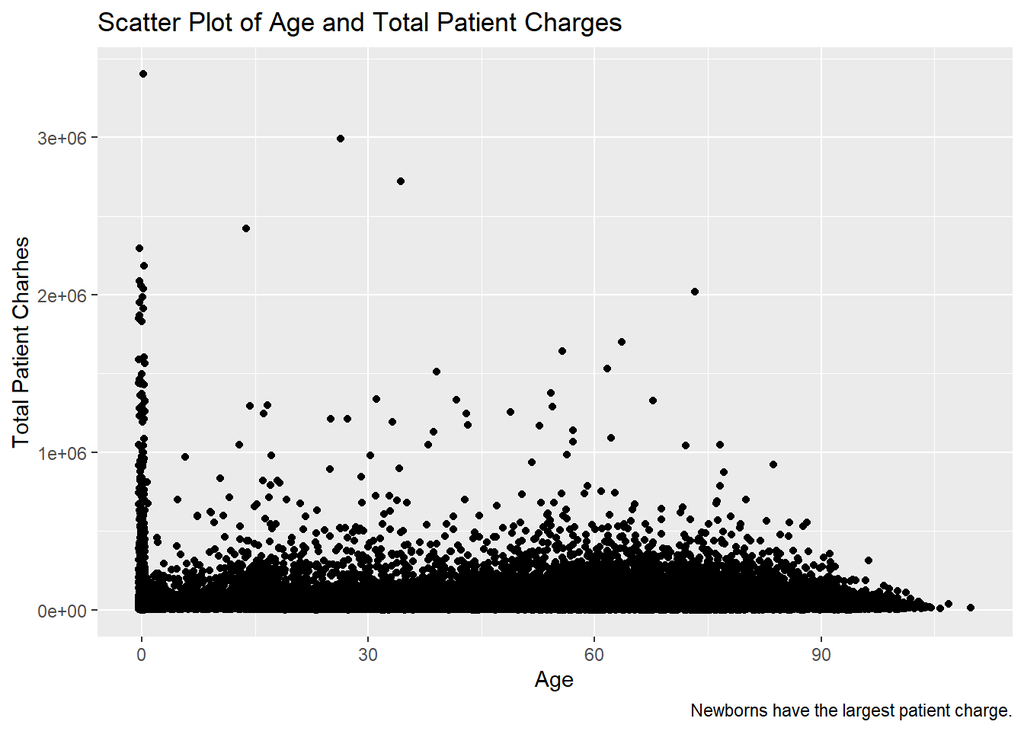

```r
df1 %>%  ggplot()+
  geom_point(mapping = aes(x= age, y= tot), position="jitter")+
  labs(x='Age',
       y = 'Total Patient Charhes',
       title = 'Scatter Plot of Age and Total Patient Charges',
       caption = 'Newborns have the largest patient charge.')
```

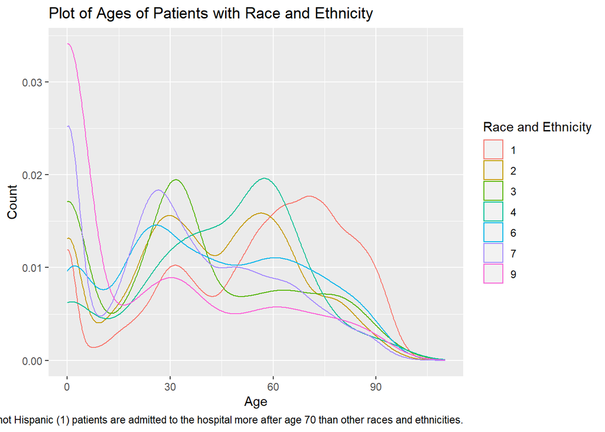

```r
df1$raceethn <- as.character(df1$raceethn)
df1 %>% ggplot()+
  geom_density(mapping = aes(x = age , color = raceethn))+
  labs(x='Age',
       y = 'Count',
       color= 'Race and Ethnicity',
       title = 'Plot of Ages of Patients with Race and Ethnicity',
       caption = 'White, or not Hispanic (1) patients are admitted to the hospital more after age 70 than other races and ethnicities.')
```

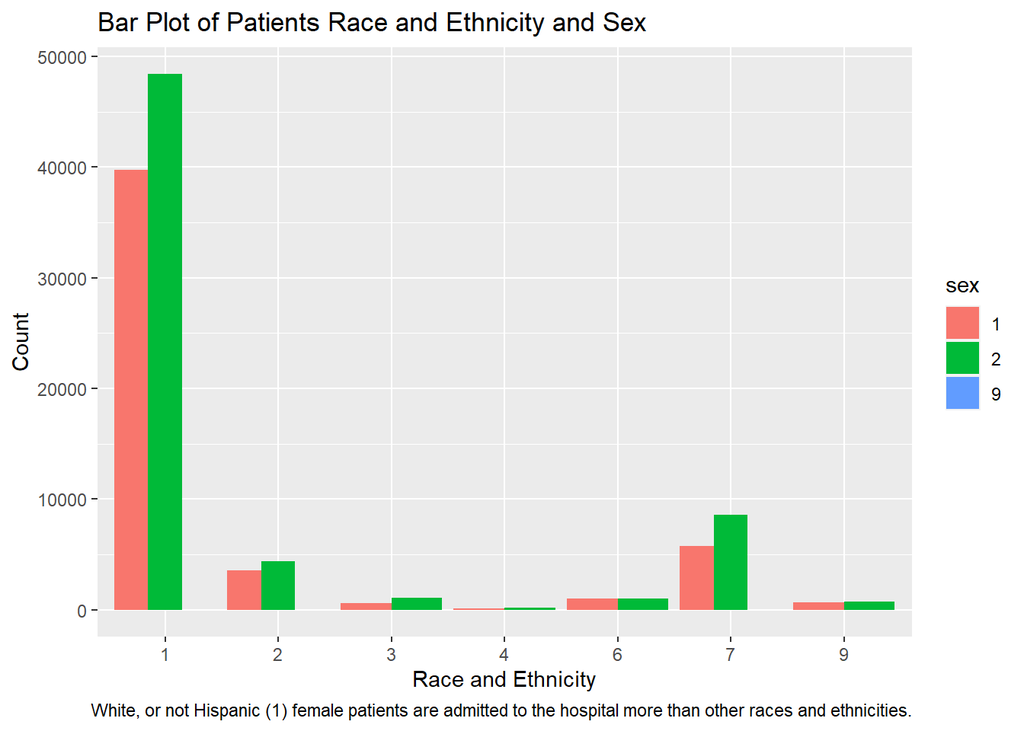

```r
df1 %>% ggplot()+
  geom_bar(mapping=aes(x=raceethn, fill=sex), position='dodge')+
  labs(x='Race and Ethnicity',
       y = 'Count',
       color= 'Sex',
       title = 'Bar Plot of Patients Race and Ethnicity and Sex',
       caption = 'White, or not Hispanic (1) female patients are admitted to the hospital more than other races and ethnicities.')
```

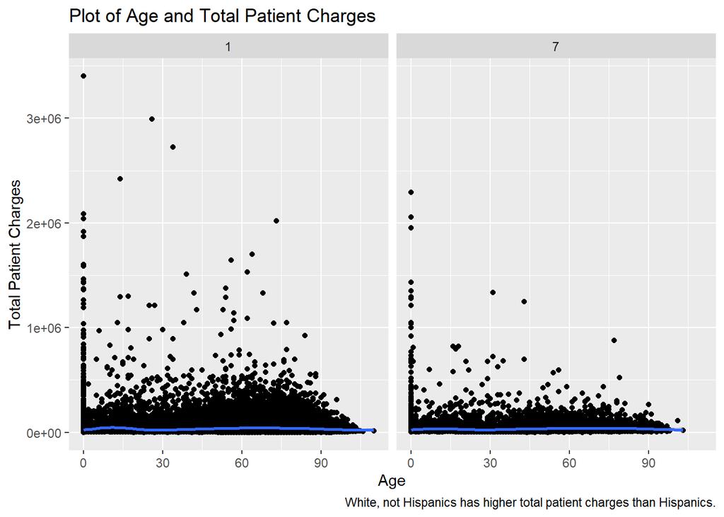

```r
df1 %>% filter(raceethn==1|raceethn==7) %>%
  ggplot(mapping=aes(x=age, y=tot))+
  geom_point()+
  geom_smooth()+
  facet_wrap(~raceethn)+
  labs(x='Age',
       y = 'Total Patient Charges',
       title = 'Plot of Age and Total Patient Charges',
       caption = 'White, not Hispanics has higher total patient charges than Hispanics.')
```

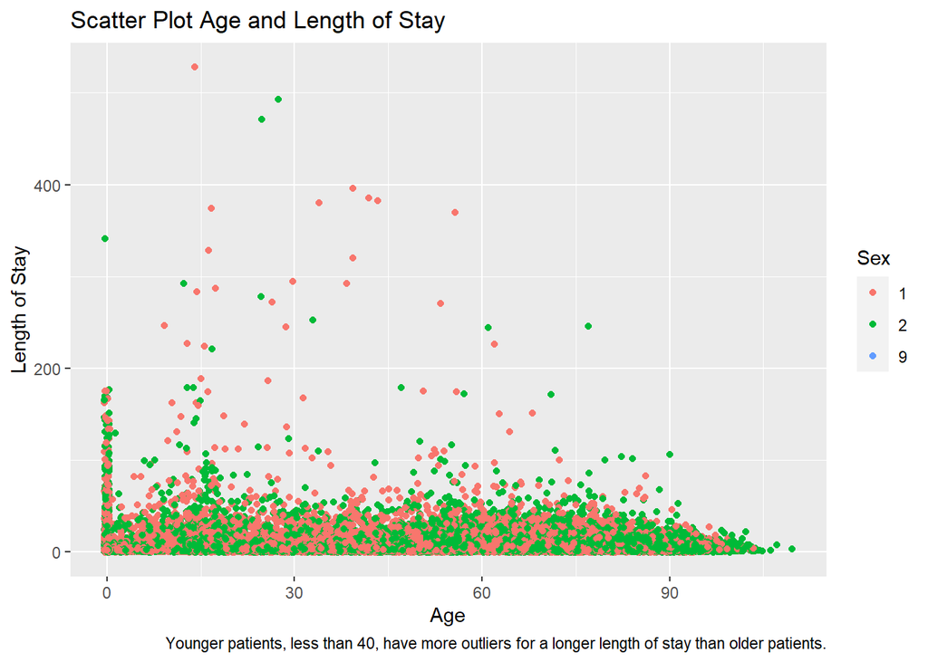

```r
df1 %>%
  ggplot()+
  geom_point(mapping=aes(x=age, y=los, color=sex), position='jitter')+
  labs(x='Age',
       y = 'Length of Stay',
       color='Sex',
       title = 'Scatter Plot Age and Length of Stay',
       caption = 'Younger patients, less than 40, have more outliers for a longer length of stay than older patients.')
```

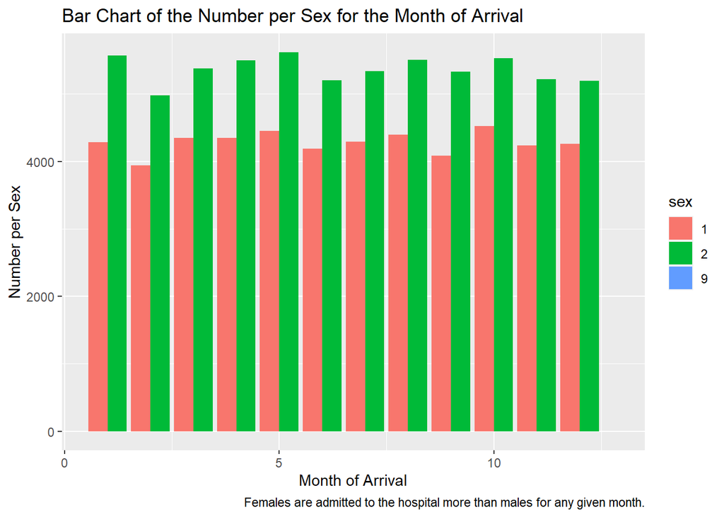

```r
df1 %>% ggplot()+
  geom_bar(mapping=aes(x=moa, fill=sex),
           position = 'dodge')+
  labs(x='Month of Arrival',
       y = 'Number per Sex',
       color='Sex',
       title = 'Bar Chart of the Number per Sex for the Month of Arrival',
       caption = 'Females are admitted to the hospital more than males for any given month.')
```

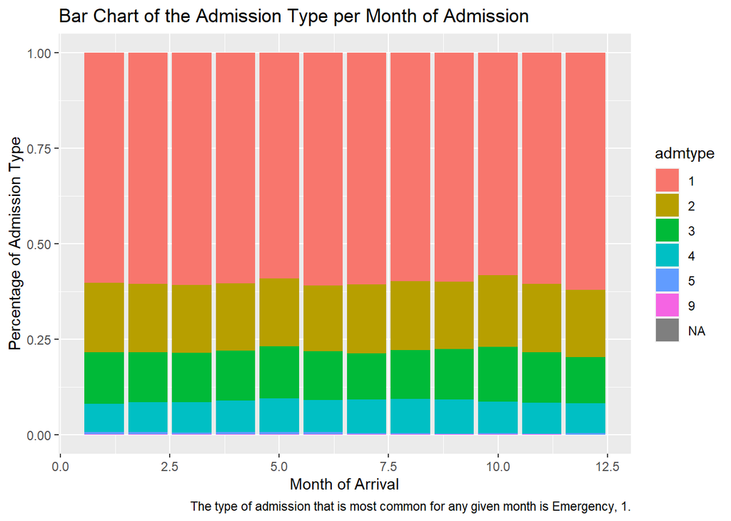

```r
df1$admtype <- as.character(df1$admtype)
df1 %>% ggplot()+
  geom_bar(mapping=aes(x=moa, fill=admtype),
           position = 'fill')+
  labs(x='Month of Arrival',
       y = 'Percentage of Admission Type',
       color='Admission Type',
       title = 'Bar Chart of the Admission Type per Month of Admission',
       caption = 'The type of admission that is most common for any given month is Emergency, 1.')
```

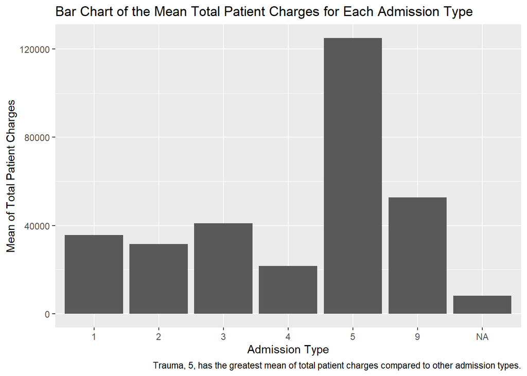

```r
df1 %>% group_by(admtype) %>% summarise(mean=mean(tot)) %>%
  ggplot()+
  geom_col(mapping=aes(x=admtype, y=mean))+
  labs(x='Admission Type',
       y = 'Mean of Total Patient Charges',
       title = 'Bar Chart of the Mean Total Patient Charges for Each Admission Type',
       caption = 'Trauma, 5, has the greatest mean of total patient charges compared to other admission types.')
```

2. Make an animation

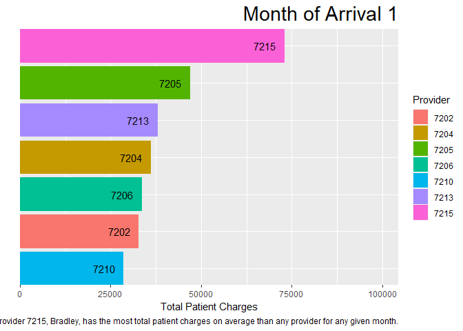

```r
library(gganimate)
library(ggplot2)
library(tidyverse)
library(knitr)
library(lubridate)
d1 <- df %>% group_by(moa, provider) %>% summarise(mean = mean(tot))
d2 <- d1 %>% group_by(moa) %>% mutate(rank=rank(-mean)) %>% ungroup()
d3 <- d2 %>% filter(rank <= 7)
a1 <- d3 %>% ggplot(aes(x=rank, y=mean, group=provider, fill= provider, label=provider)) + geom_col()+
    geom_text(aes(y = mean, label = provider), hjust = 1.4)+
    coord_flip(clip = "off", expand = FALSE) +scale_x_reverse()+
    labs(title = 'Month of Arrival {closest_state}', x='', y='Total Patient Charges', fill='Provider', caption = 'Provider 7215, Bradley, has the most total patient charges on average than any provider for any given month.')+
    theme(plot.title = element_text(hjust = 1, size = 22),
          axis.ticks.y = element_blank(),
          axis.text.y  = element_blank()) +
    transition_states(moa)+
    ease_aes("cubic-in-out")
animate(a1, nframes = 400, fps = 10)
```

## III. Predictive Models

Continue with the data from part I. Use the follows as the target and input variables:

*Target Variable*: Create the target variable taking value of

- `low cost` if the total charge of a patient (`tot`) is smaller than the median of the total charge, and
- `high cost` otherwise.

```r
median(df1$tot)
```

```
## [1] 22050
```

```r
df1$target <- case_when(
  df1$tot <22050 ~ 'low cost',
  TRUE ~ 'high cost')
```

*Input Variables*:

- “age”,“sex”,“raceethn”,“provider”,“moa”,“mod”,“campus”, “er_mode”, ‘los’

```r
df2 <- select(df1,"age","sex","raceethn","provider","moa","mod","campus", "er_mode", "los","target")
```

1. Make sure all the categorical variables are factor, numeric variables are numeric. Set Training : Testing Split = 10 : 90

```r
library(caret)
df2$moa <- as.character(df2$moa)
df2$mod <- as.character(df2$mod)

set.seed(2020)
splitIndex <- createDataPartition(df2$target , p = .10, list = FALSE)
df_train <- df2[ splitIndex,]
df_test <- df2[-splitIndex,]
```

2. Train a decision tree using `rpart`. Plot the decision tree. Plot the variable importance ranked by the tree.

```r
library(rpart)
tree_model <- rpart(target ~ ., data = df_train,
                 control = rpart.control(maxdepth = 3))
library(rattle)
```

[figure not shown]

```r
fancyRpartPlot(tree_model)
```

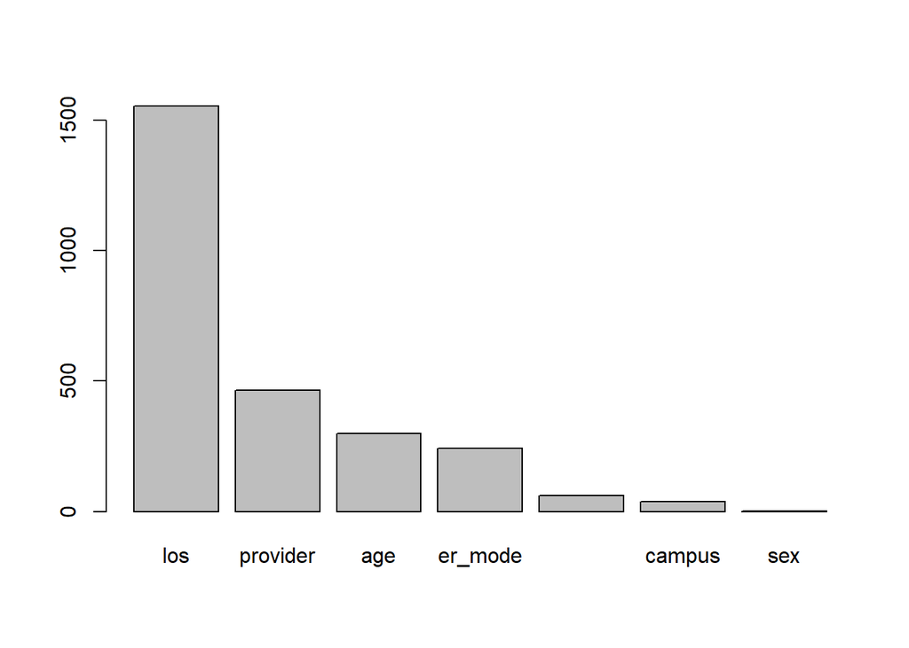

```r
barplot(tree_model$variable.importance)
```

3. Using caret for this question. Set `Training Control` to be: Use Cross-Validation of 5 folds across all models. Train & tune at least 3 different models (i.e. three different values for `method=` in the train function of caret). Plot the hyper-parameter tuning plots for each model.

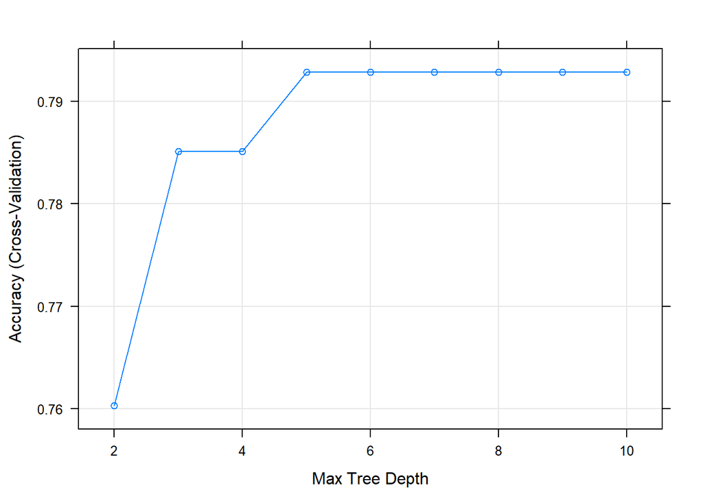

```r
library(caret)

tuneGrid = expand.grid(maxdepth = 2:10)
trControl = trainControl(method = "cv",
                         number = 5)
tree_approach <- train(target~., data=df_train,
                                method = "rpart2",
                                trControl = trControl,
                                tuneGrid = tuneGrid)
plot(tree_approach)
```

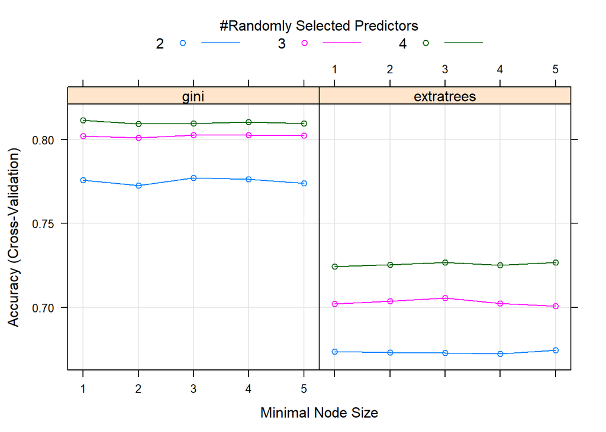

```r
library(rpart)
library(rpart.plot)
trControl = trainControl(method = "cv",
                         number = 5)
tuneGrid = expand.grid(mtry = 2:4,
                       splitrule = c('gini', 'extratrees'),
                       min.node.size = c(1:5))
ranger_cv <- train(target~., data=df_train,
                    method = "ranger",
                    trControl = trControl,
                    tuneGrid = tuneGrid)
plot(ranger_cv)
```

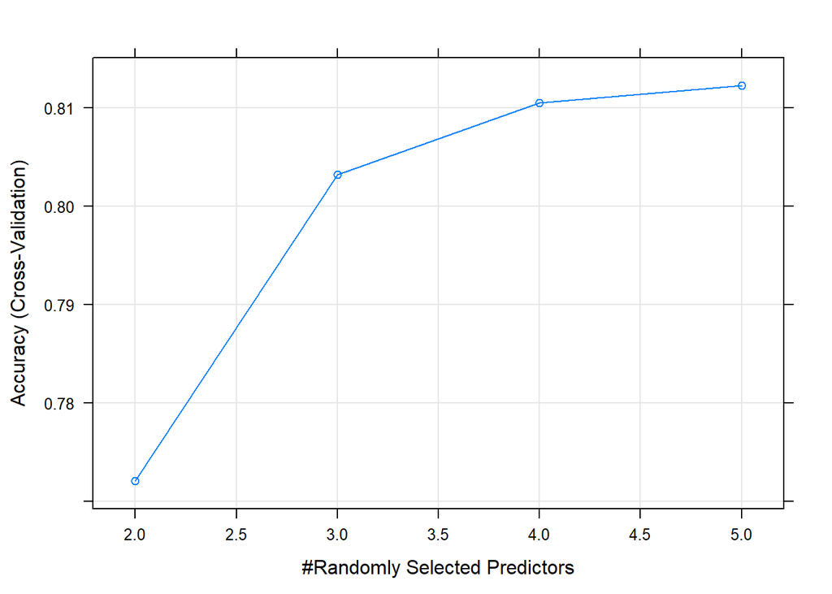

```r
tuneGrid = expand.grid(mtry = 2:5)
trControl = trainControl(method = "cv",
                         number = 5)
forest_cv <- train(target~., data=df_train,
                                method = "rf",
                                trControl = trControl,
                                tuneGrid = tuneGrid)
plot(forest_cv)
```

4. Plot the comparison of the models in 2.

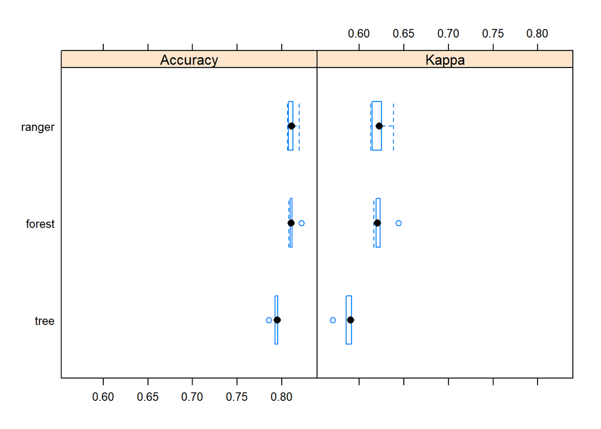

```r
results <- resamples(list(forest = forest_cv,
                          ranger = ranger_cv,
                          tree= tree_approach))
bwplot(results)
```

5. What is your final selection for the model? Test the accuracy of your final model on the test data.

```r
pred <- predict(ranger_cv, df_test)
cm <- confusionMatrix(data = factor(pred), reference = factor(df_test$target), positive = "high cost")
cm$overall[1]
```

```
##  Accuracy
## 0.8100917
```

6. Create another `target` variable (binary), decide the input variables and redo 1 to 5.

```r
median(df1$los)
```

```
## [1] 3
```

```r
df1$target1 <- case_when(
  df1$los <3 ~ 'short stay',
  TRUE ~ 'long stay')

df3 <- select(df1,"age","sex","raceethn","provider","moa","mod","campus", "er_mode", "tot","target1")
```

```r
set.seed(2020)
splitIndex <- createDataPartition(df3$target1 , p = .10, list = FALSE)
df_train1 <- df3[ splitIndex,]
df_test1 <- df3[-splitIndex,]
```

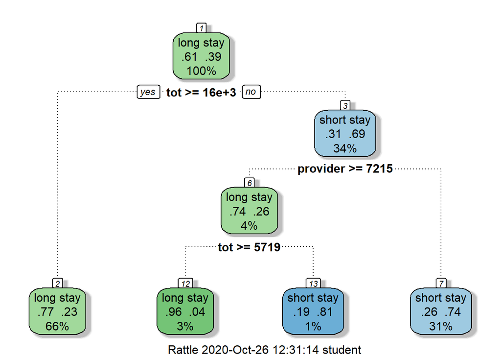

```r
library(rpart)
treeModel <- rpart(target1 ~ ., data = df_train1,
                 control = rpart.control(maxdepth = 3))
library(rattle)
fancyRpartPlot(treeModel)
```

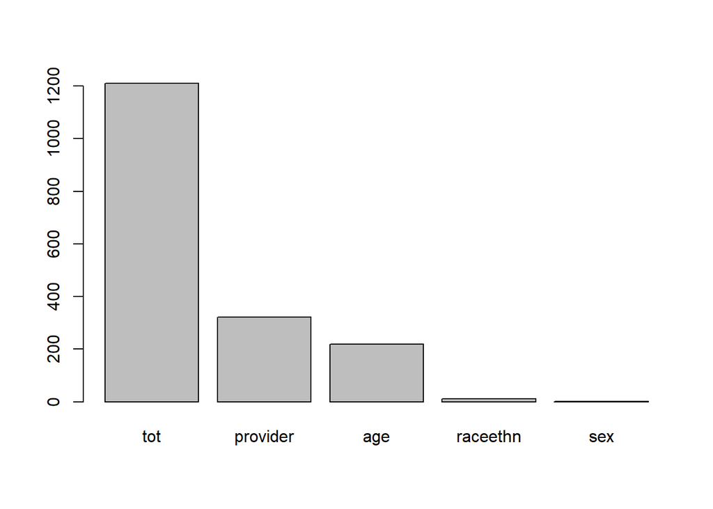

```r
barplot(treeModel$variable.importance)
```

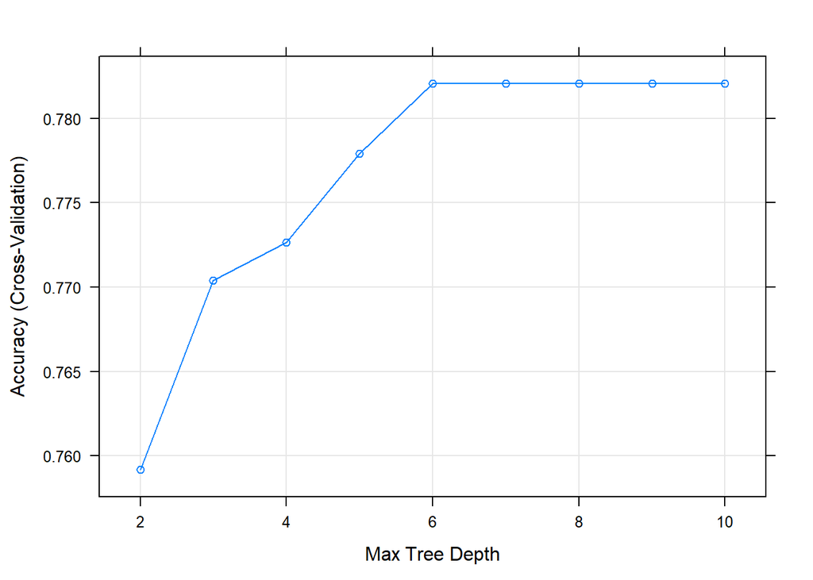

```r
library(caret)

tuneGrid = expand.grid(maxdepth = 2:10)
trControl = trainControl(method = "cv",
                         number = 5)
treeApproach <- train(target1~., data=df_train1,
                                method = "rpart2",
                                trControl = trControl,
                                tuneGrid = tuneGrid)
plot(treeApproach)
```

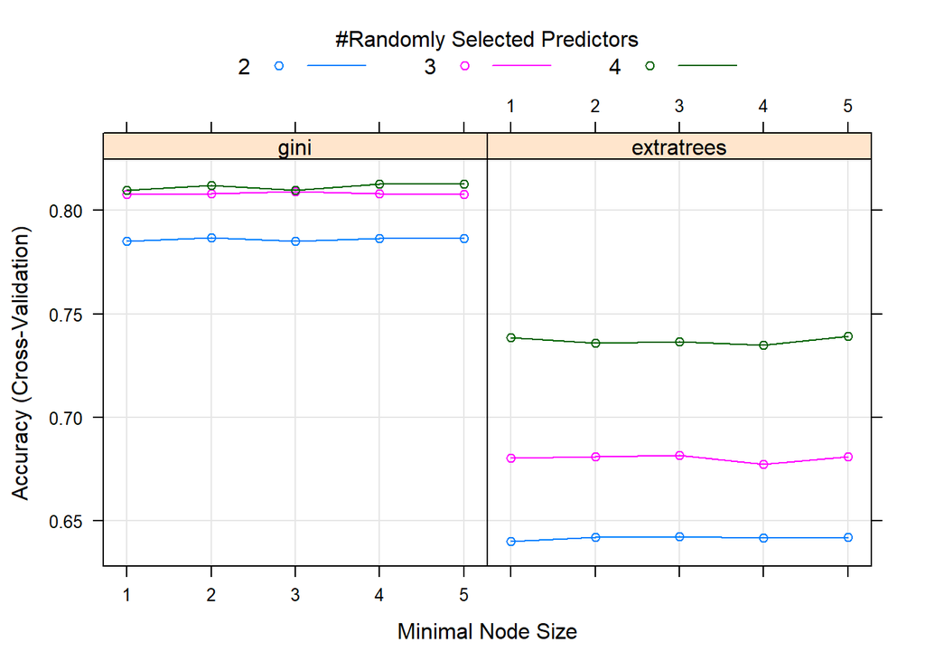

```r
library(tidyverse)
library(caret)
library(rpart)
trControl = trainControl(method = "cv",
                         number = 5)
tuneGrid = expand.grid(mtry = 2:4,
                       splitrule = c('gini', 'extratrees'),
                       min.node.size = c(1:5))
rangerCv <- train(target1~., data=df_train1,
                    method = "ranger",
                    trControl = trControl,
                    tuneGrid = tuneGrid)
plot(rangerCv)
```

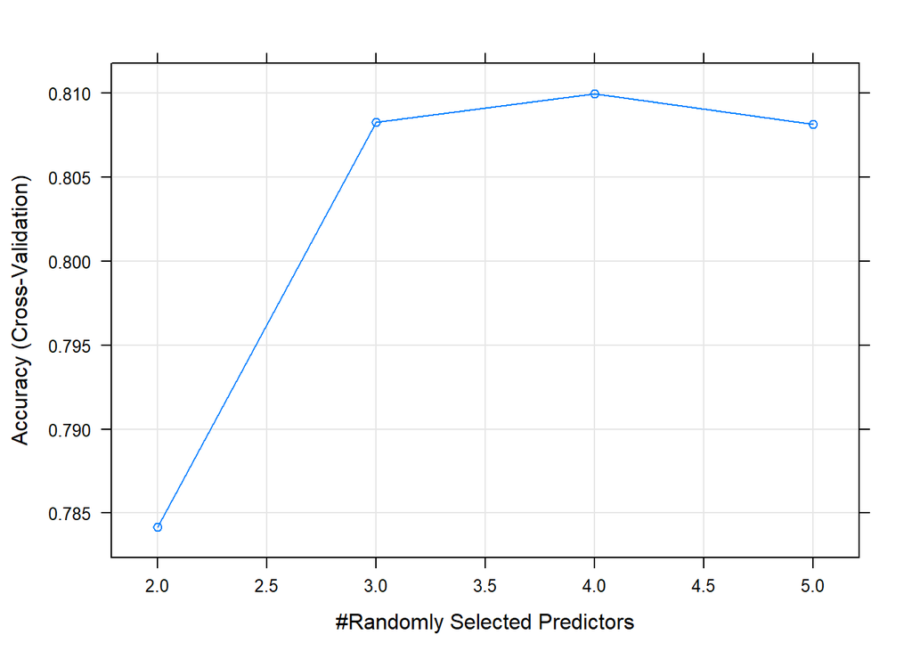

```r
tuneGrid = expand.grid(mtry = 2:5)
trControl = trainControl(method = "cv",
                         number = 5)
forestCv <- train(target1~., data=df_train1,
                                method = "rf",
                                trControl = trControl,
                                tuneGrid = tuneGrid)
plot(forestCv)
```

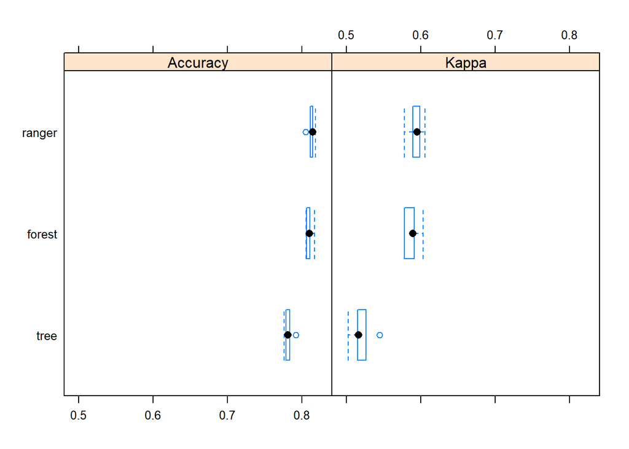

```r
results <- resamples(list(forest = forestCv,
                          ranger = rangerCv,
                          tree= treeApproach))
bwplot(results)
```

```r
pred <- predict(rangerCv, df_test1)
cm <- confusionMatrix(data = factor(pred), reference = factor(df_test1$target1), positive = "long stay")
cm$overall[1]
```

```
##  Accuracy
## 0.8065467
```